# Apple by Example

Vanessa McHale

# Introduction

Apple is an experimental compiler with a typed frontend inhabited by two demons.

## Installation

The REPL and typechecker are available on the [release page](https://github.com/vmchale/apple/releases).

## Reference Card

In the REPL, type `\l`.

```
vanessa@MacBookAir apple % arepl
 > \l
Λ             scan                     √             sqrt
⋉             max                      ⋊             min
⍳             integer range            ⌊, ⌈          floor, ceiling
e:            exp                      ⨳ {m,n}       convolve
\~            successive application   \`n           infix
_.            log                      '             map
`             zip                      `{i,j∘[k,l]}  rank
𝒻             range (real)             𝜋             pi
⋮
```

Use `:ty` for more:

```
 > :ty (⊲)
a → Vec i a → Vec (i + 1) a
```

`:help` inside the REPL:

```
 > :help
:help, :h                    Show this help
:ty            <expression>  Display the type of an expression
:ann           <expression>  Annotate with types
:bench, :b     <expression>  Benchmark an expression
:list                        List all names that are in scope
⋮
```

## Editor Integration

There is a [vim plugin](https://github.com/vmchale/apple/tree/canon/vim) and a [VSCode extension](https://marketplace.visualstudio.com/items?itemName=vmchale.apple).

The file extension is `.🍎` or `.🍏`.

# Capabilities

## Range (Integer)

To generate an integer range use `..`

```
(..)
    : int → int → Vec #n int
```

`..` is a binary operator taking a start value and end value as arguments, viz.

```
 > 1..9
Vec 9 [1, 2, 3, 4, 5, 6, 7, 8, 9]
```

## Iota

`⍳` generates an integer range beginning with 0.

```
 > ⍳
⍳
    : int(n) → Vec (n + 1) int
```

```
 > ⍳9
Vec 10 [0, 1, 2, 3, 4, 5, 6, 7, 8, 9]
```

## Real Range

For a range of real numbers, use `frange` or `𝒻`.

```
 > :ty frange
float → float → int → Vec #n float
```

`frange` takes a start value, an end value, and the number of steps.

```
 > frange 0 9 10
[0.0, 1.0, 2.0, 3.0, 4.0, 5.0, 6.0, 7.0, 8.0, 9.0]
```

## Map

`'` maps over an array.

```
 > (*2)'⍳ 0 9
[0, 2, 4, 6, 8, 10, 12, 14, 16, 18]
```

Functions can be [curried](https://wiki.haskell.org/Currying).

## Zip

Pick the greater value among two vectors:

```
 > (⋉)`⟨0,_1,3.0⟩ ⟨_3,1,3⟩
Vec 3 [0.0, 1.0, 3.0]
```

## Fold

`/` folds over an array.

```
 > (+)/⍳ 1 100
5050
```

## Scan

```
 > (+)Λ 1..3
Vec 3 [1, 3, 6]
```

## Array Literals

Array literals are delineated by `⟨`…`⟩`.

```
 > ⟨_1,0::int⟩
[-1, 0]
```

```
 > ⟨⟨0,1⟩,⟨_1,0::int⟩⟩
[ [0, 1]
, [-1, 0] ]
```

### Compact Numeric Literals

```
𝔸21
```

will be interpreted as

```
⟨2,1⟩
```

This only works for single-digit numbers, but cosmically justified numbers [tend to be small](https://groups.google.com/g/shaktidb/c/sYcklkglN8w/m/Vf-qdfx3AgAJ).

## Sort

`⍋` sorts a numeric array.

```
 > ⍋ (rand. _20 20 :: Vec 13 int)
Vec 13 [-17, -13, -10, -9, -7, -7, -7, -5, 2, 3, 4, 12, 17]
```

## Axis

`ᶥ` (postfix) returns a vector of indices with the same length as the leading axis of its argument.

```
 > :ty [xᶥ]
Vec i a → Vec i int
```

```
 > frange _10 0 11
Vec 11 [-10.0, -9.0, -8.0, -7.0, -6.0, -5.0, -4.0, -3.0, -2.0, -1.0, 0.0]
 > (frange _10 0 11)ᶥ
Vec 11 [0, 1, 2, 3, 4, 5, 6, 7, 8, 9, 10]
```

## Reverse

`~` reverses an array.

```
 > ~(⍳9)
[9, 8, 7, 6, 5, 4, 3, 2, 1, 0]
```

Reverse applied to a higher-dimensional array reverses elements (sub-arrays) along the first dimension.

```
 > ⟨⟨0,1⟩,⟨1,0::int⟩,⟨2,4⟩⟩
[ [0, 1]
, [1, 0]
, [2, 4] ]
 > ~⟨⟨0,1⟩,⟨1,0::int⟩,⟨2,4⟩⟩
[ [2, 4]
, [1, 0]
, [0, 1] ]
```

```
 > ~'⟨⟨0,1⟩,⟨1,0::int⟩,⟨2,4⟩⟩
[ [1, 0]
, [0, 1]
, [4, 2] ]
```

## Outer Product

The outer product `⊗` creates a table by applying some function.

```
 > :ty \f.\x.\y. x f⊗ y
(a → b → c) → Arr sh0 a → Arr sh1 b → Arr (sh0 ⧺ sh1) c
```

```
 > (frange 0 9 10) (*)⊗ (frange 0 9 10)
[ [0.0, 0.0, 0.0, 0.0, 0.0, 0.0, 0.0, 0.0, 0.0, 0.0]
, [0.0, 1.0, 2.0, 3.0, 4.0, 5.0, 6.0, 7.0, 8.0, 9.0]
, [0.0, 2.0, 4.0, 6.0, 8.0, 10.0, 12.0, 14.0, 16.0, 18.0]
, [0.0, 3.0, 6.0, 9.0, 12.0, 15.0, 18.0, 21.0, 24.0, 27.0]
, [0.0, 4.0, 8.0, 12.0, 16.0, 20.0, 24.0, 28.0, 32.0, 36.0]
, [0.0, 5.0, 10.0, 15.0, 20.0, 25.0, 30.0, 35.0, 40.0, 45.0]
, [0.0, 6.0, 12.0, 18.0, 24.0, 30.0, 36.0, 42.0, 48.0, 54.0]
, [0.0, 7.0, 14.0, 21.0, 28.0, 35.0, 42.0, 49.0, 56.0, 63.0]
, [0.0, 8.0, 16.0, 24.0, 32.0, 40.0, 48.0, 56.0, 64.0, 72.0]
, [0.0, 9.0, 18.0, 27.0, 36.0, 45.0, 54.0, 63.0, 72.0, 81.0] ]
```

```
 > (frange 0 4 5) [(x,y)]⊗ (frange 0 4 5)
[ [(0.0*0.0), (0.0*1.0), (0.0*2.0), (0.0*3.0), (0.0*4.0)]
, [(1.0*0.0), (1.0*1.0), (1.0*2.0), (1.0*3.0), (1.0*4.0)]
, [(2.0*0.0), (2.0*1.0), (2.0*2.0), (2.0*3.0), (2.0*4.0)]
, [(3.0*0.0), (3.0*1.0), (3.0*2.0), (3.0*3.0), (3.0*4.0)]
, [(4.0*0.0), (4.0*1.0), (4.0*2.0), (4.0*3.0), (4.0*4.0)] ]
```

## Reshape

`♭` flattens an array to a vector, `♯` adds a dimension.

```
 > :ty λA. ♭ (A::Arr (28×28×1) a)
Arr (28 × 28 × 1) a → Vec 784 a
 > ♯ (⍳9)
Arr (1×10) [ [0, 1, 2, 3, 4, 5, 6, 7, 8, 9] ]
```

## Successive Application

```
 > :ty (\~)
(a → a → b) → Arr (i + 1 `Cons` sh) a → Arr (i `Cons` sh) b
```

`[(-)\~ x]` gives successive differences.

```
 > (-)\~ ((^2)'(frange 0 9 10))
[1.0, 3.0, 5.0, 7.0, 9.0, 11.0, 13.0, 15.0, 17.0]
```

## Rotate

```
 > (⊖)
(⊖) : int → Vec i a → Vec i a
```

```
 > 2 ⊖ ⍳9
[2, 3, 4, 5, 6, 7, 8, 9, 0, 1]
 > _2 ⊖ ⍳9
[8, 9, 0, 1, 2, 3, 4, 5, 6, 7]
```

```
 > 2 ⊖ ⟨⟨1,2⟩,⟨3,4⟩,⟨5,6.0⟩⟩
Arr (3×2) [ [5.0, 6.0]
          , [1.0, 2.0]
          , [3.0, 4.0] ]
```

## Cycle

`cyc.` or `⊙` (infix) concatenates an array with itself a specified number of times.

```
 > cyc. ⟨0::int,1⟩ 4
Vec 8 [0, 1, 0, 1, 0, 1, 0, 1]
```

```
 > ⟨0::int,1⟩⊙4
Vec 8 [0, 1, 0, 1, 0, 1, 0, 1]
```

## Repeat

```
 > ⟨1.0,0⟩〃3
Arr (3×2) [ [1.0, 0.0]
          , [1.0, 0.0]
          , [1.0, 0.0] ]
```

## Transpose

⍉ or `|:`

```
 > ⍉ ⟨⟨1.0,3⟩,⟨4,4⟩,⟨2,_2⟩⟩
[ [1.0, 4.0, 2.0]
, [3.0, 4.0, -2.0] ]
 > ⟨⟨1.0,3⟩,⟨4,4⟩,⟨2,_2⟩⟩
[ [1.0, 3.0]
, [4.0, 4.0]
, [2.0, -2.0] ]
```

## Unfold

```
 > gen. (1::int) (*2) 10
Vec 10 [1, 2, 4, 8, 16, 32, 64, 128, 256, 512]
```

## Infix

Moving average:

```
 > [(+)/x%ℝ(:x)]\` 7 (frange 0 9 10)
[3.0, 4.0, 5.0, 6.0]
```

```
 > [x]\`4 (frange 0 5 6)
[ [0.0, 1.0, 2.0, 3.0]
, [1.0, 2.0, 3.0, 4.0]
, [2.0, 3.0, 4.0, 5.0] ]
```

## Bind

```
 > {i←2::int;i*i}
4
```

Bind, preventing inlining:

```
 > {i⟜2::int;i*i}
4
```

One can see that `2` is stored in a register by inspecting the generated assembly:

```
 > :asm {i←2::int;i*i}

    mov x0, #0x4
    ret
 > :asm {i⟜2::int;i*i}

    mov x0, #0x2
    mul x0, x0, x0
    ret
```

### Polymorphic Bind

```
 > {sum ⇐ [(+)/x]; sum (⍳ 9)+⌊(sum(frange 0 9 10))}
90
```

```
 > {sum ← [(+)/x]; sum (⍳ 9)+⌊(sum(frange 0 9 10))}
1:42: could not unify 'float' with 'int' in expression '𝒻 0 9 10'
```

## Strong Induction

`𝓕` is like `gen.` but with access to all previously computed values.

```
 > :ty 𝓕
Vec m a → (Vec k a → a) → int(n) → Vec (m + n) a
```

Fibonacci sequence:

[output not shown]

## Unfold With State

```
 > :ty ug.
(b → (b * a)) → b → int(n) → Vec n a
```

## Rank

Rank ``{i,j∘[k,l]}` or ``{i,j[k,l]}` lifts a function to operate on i, j-cells, optionally specifying axes k,l. Iteration is bottom-up; by contrast map `'` cuts across the leading dimension.

To make a scalar function apply to arrays, re-rank

```
 > :ty ((*)`{0,0})
(IsNum c) :=> Arr sh c → Arr sh c → Arr sh c
```

Sigmoid on an arbitrary-dimension array:

```python
([1%(1+e:(_x))]`{0})
```

```
 > ⟨⟨0,1,2⟩,⟨3,4,5::int⟩⟩
Arr (2×3) [ [0, 1, 2]
          , [3, 4, 5] ]
 > ((+)/)`{1} ⟨⟨0,1,2⟩,⟨3,4,5::int⟩⟩
Vec 3 [3, 5, 7]
 > ((+)/)`{1∘[2]} ⟨⟨0,1,2⟩,⟨3,4,5::int⟩⟩
Vec 2 [3, 12]
```

This may be confusing; Apple’s rank feature was poorly designed.

Take 0-cells (scalars) from the first array and 1-cells from the second.

```
 > (⊲)`{0,1[2]} ⟨0::int,1⟩ ⟨⟨2,3⟩,⟨4,5⟩⟩
Arr (2×3) [ [0, 2, 3]
          , [1, 4, 5] ]
```

```
 > ⍉ ((2 ⊖)`{1} ⟨⟨1,2⟩,⟨3,4⟩,⟨5,6.0⟩⟩)
Arr (3×2) [ [5.0, 6.0]
          , [1.0, 2.0]
          , [3.0, 4.0] ]
```

```
 > :ty [♭`{3∘[2,3,4]} (x :: Arr (60000 × 28 × 28 × 1) float)]
Arr (60000 × 28 × 28 × 1) float → Arr (60000 × 784) float
```

### Sum Axes

```
 > :store a ⟨⟨⟨0::int,1,2,3⟩,⟨4,5,6,7⟩,⟨8,9,10,11⟩⟩,⟨⟨12,13,14,15⟩,⟨16,17,18,19⟩,⟨20,21,22,23⟩⟩⟩
 > ((+)/)`{1} a
Arr (3×4) [ [12, 14, 16, 18]
          , [20, 22, 24, 26]
          , [28, 30, 32, 34] ]
 > ((+)/)`{1∘[2]} a
Arr (2×4) [ [12, 15, 18, 21]
          , [48, 51, 54, 57] ]
 > ((+)/)`{1∘[3]} a
Arr (2×3) [ [6, 22, 38]
          , [54, 70, 86] ]
 > [(+)/* 0 x]`{2} a
Vec 4 [60, 66, 72, 78]
 > [(+)/* 0 x]`{2∘[1,3]} a
Vec 3 [60, 92, 124]
 > [(+)/* 0 x]`{2∘[2,3]} a
Vec 2 [66, 210]
```

For comparison:

```
 > [(+)/* 0 (x::M int)]'a
Vec 2 [66, 210]
 > (+)/* 0 a
276
```

## Dot Product

`x⋅y` is shorthand for `` (+)/(*)`x y ``.

## Random Numbers

`𝔯` or `rand.`

```
 > 𝔯 0 1 :: float
0.582699021207219
 > 𝔯 0 1 :: Arr (3 × 3) float
Arr (3×3) [ [0.9827522631010304, 0.30678513061418045, 0.6008551364891055]
          , [0.608715653358658, 0.2124387982011875, 0.8858951305876062]
          , [0.30465710174579286, 0.15185986406856955, 0.33766190287353126] ]
```

## Tuples

Use `->n` to access the `n`th element of a tuple, viz.

```
 > (1.0,#t,4::int)->1
1.0
 > (1.0,#t,4::int)->2
#t
 > (1.0,#t,4::int)->3
4
```

## Convolve

Convolve `(⨳ {m,n})` is like infix for higher-rank windows. One can also write `(# {m,n})`.

```
 > [(⋉)/x] ⨳ {3} ⟨_1,0,4,_2,3,3,1,1,0,_5.0⟩
Vec 8 [4.0, 4.0, 4.0, 3.0, 3.0, 3.0, 1.0, 1.0]
```

```
 > [(⋉)/x] \`3 ⟨_1,0,4,_2,3,3,1,1,0,_5.0⟩
Vec 8 [4.0, 4.0, 4.0, 3.0, 3.0, 3.0, 1.0, 1.0]
```

```
 > ([(+)/* 0 (x::Arr (2×3) float)%ℝ(:x)] # {2,3}) ⟨⟨1.0,2,0,0⟩,⟨_1,_2,3,4⟩,⟨5,6,3,1⟩,⟨3,1,1,3⟩⟩
Arr (3×2) [ [0.5, 1.1666666666666665]
          , [2.333333333333333, 2.5]
          , [3.1666666666666665, 2.5] ]
```

`(⨳ {m∘k,n∘l})` specifies the skip between windows/blocks, viz.

```
 > ([(⋉)/* _1e100 (x::M float)] ⨳ {2∘2,2∘2}) ⟨⟨20.0,200,_5,23⟩,⟨_13,134,119,100⟩,⟨120,32,49,25⟩,⟨_120,12,9,23⟩⟩
Arr (2×2) [ [200.0, 119.0]
          , [120.0, 49.0] ]
 > ([(⋉)/* _1e100 (x::M float)] ⨳ {2,2∘2}) ⟨⟨20.0,200,_5,23⟩,⟨_13,134,119,100⟩,⟨120,32,49,25⟩,⟨_120,12,9,23⟩⟩
Arr (3×2) [ [200.0, 119.0]
          , [134.0, 119.0]
          , [120.0, 49.0] ]
```

## Combinators

### S, K

```
 > :ty 𝐒
(a → b → c) → (a → b) → a → c
 > :ty 𝐊
b → a → b
```

### Fork

Haskell’s [`on`](https://hackage.haskell.org/package/base-4.21.0.0/docs/Data-Function.html#v:on), [Curry’s Φ combinator](https://dl.acm.org/doi/10.1145/3520306.3534504)):

```
 > :ty (⑂)
(b → b → c) → (a → b) → a → a → c
```

One can define the logarithm in any base from the natural logarithm `_.`, viz.

```
 > ([y%x]⑂_.) 2 8
3.0
```

### Odd Functions

```
 > :ty refl.
(float → float) → float → float
```

Computes odd functions from the positive half. [Arcsine](https://16bpp.net/blog/post/faster-asin-was-hiding-in-plain-sight/):

```python
refl. (λz. {
  as ⟜ ⟨1.5707288,_0.2121144,0.0742610,_0.0187293⟩;
  Ho ← gen. 1 (z*) 4;
  𝜋%2-√(1-z)*Ho⋅as
})
```

## REPL Functionality

### Load

```
 > :yank chisqcdf math/chisqcdf.🍎
 > chisqcdf 10 28
0.9982004955179669
```

`math/chisqcdf.🍎` is a file that contains an expression of type `float → float→ float`.

### Benchmark

```
 > :bench frange 0 999 1000
benchmarking...
time                 1.423 μs   (1.417 μs .. 1.427 μs)
                     1.000 R²   (1.000 R² .. 1.000 R²)
mean                 1.426 μs   (1.422 μs .. 1.429 μs)
std dev              11.94 ns   (9.819 ns .. 14.22 ns)
```

### QuickCheck

Apple can generate shape-correct test cases for property testing. For instance,

```
 > :qc \x. [(+)/(*)`x y] x x >= 0.0
Passed, 100.
```

tests that the dot product of a vector with itself is nonnegative.

## Exotic Syntax

### Coronis

Instead of

```python
{x←y;z}
```

One can write

```python
⸎x←y;z
```

Using the typographical coronis.

### Matrix Dimensions

One can specify matrix dimensions in a type signature with unicode subscript digits separated by a comma.

```python
𝔯 0 1 :: M ₁₂,₁₂ float
```

is equivalent to

```python
𝔯 0 1 :: Arr (12 × 12) float
```

### Identifiers

Identifiers may be latin or greek characters, or a single character from the mathematical greek or mathematical latin unicode block, optionally followed by some subscript alphanumeric characters. `∂` may appear at the beginning of multi-character identifiers or on its own. The single-character lambda `λ` is reserved. `∫`, `𝛻`, and `∇` are also identifiers but may not be followed by a subscript.

Thus `pxs`, `aₙ`, `sn₁`, `𝐶`, `φs`, `∂f`, `𝜉`, and `𝜌₀` are valid identifiers but `𝜉s`, `𝜉∂`, and `f∂` are parsed as application of one identifier to another.

### Vulgar Fractions

Unicode vulgar fractions are considered float literals:

```
 > ⅚
0.8333333333333334
```

One can use `⅟` for the reciprocal, viz.

```
 > [⅟(1+e:(_x))]
λx. 1.0 % (1 + 2.718281828459045 ** _ x) : float → float
```

### Time

In the REPL, one can use `⏱` in place of `:bench`, i.e.

```
> ⏱ [(+)/x%ℝ(:x)]\`7 (𝒻 0 999 1000)
```

### Type Shorthands

`𝟘` can be used in place of `int`, viz.

```
 > 17*3::𝟘
51
 > 𝔯 1 6::𝟘
5
 > 𝔯 1 6::Vec 6 𝟘
Vec 6 [6, 2, 1, 5, 5, 3]
```

`𝞈` is shorthand for `float`.

```
 > 𝔯 0 1::𝞈
0.8404853694114252
```

`𝟙` is shorthand for `Vec n`, `n` an index variable. `𝟚` is a synonym for `M`.

# Examples

## Cross Product

The cross product of two vectors $(a_1,a_2,a_3)$, $(b_1,b_2,b_3) \in \mathbb{R}^3$ is the vector $\in\mathbb{R}^3$

$$(a_2b_3-a_3b2,
a_3b1-a_1b3,a_1b_2-a_2b_1)$$

In Apple, we can write:

```python
λa.λb. (-)`((*)`(1⊖a) (_1⊖b)) ((*)`(_1⊖a) (1⊖b))
```

This uses zips and rotations (no indices are mentioned); it is a new perspective on the problem.

## Linear Regression

```python
λxs.λys.
{
  Σ ← [(+)/x];
  n ⟜ ℝ(:xs);
  xbar ⟜ Σ xs % n; ybar ⟜ Σ ys % n;
  xy ⟜ Σ ((*)`xs ys);
  x2 ⟜ Σ ((^2)'xs);
  denom ⟜ x2-n*xbar^2;
  a ← (ybar*x2-xbar*xy)%denom;
  b ← (xy-n*xbar*ybar)%denom;
  (a,b)
}
```

Note the `⟜` to prevent expressions from being inlined.

## Kullback-Leibler Divergence

```python
λp.λq. (+)/([x*_.(x%y)]`p q)
```

## Numerically Stable Geometric Mean

```python
λxs.
  ⸎ avg ← [{n ⟜ ℝ(:xs); ((+)/xs)%n}]
  ; e:(avg (_.'xs))
```

## Array Strides

```python
λds. }:((*)Λₒ 1::int ds)
```

(Column-major order)

## Train Neural Network

```python
λwh.λwo.λbh.λbo.
{ X ⟜ ⟨⟨0,0⟩,⟨0,1⟩,⟨1,0⟩,⟨1,1⟩⟩;
  Y ← ⟨0,1,1,0⟩;
  sigmoid ← [1%(1+e:(_x))];
  sDdx ← [x*(1-x)];
  sum ⇐ [(+)/x];
  ho ⟜ sigmoid`{0} ([(+)`bh x]'(X%.wh));
  prediction ⟜ (sigmoid ∴ (+bo))'(ho%:wo);
  l1E ← (-)`Y prediction;
  l1Δ ⟜ (*)`(sDdx'prediction) l1E;
  he ← l1Δ (*)⊗ wo;
  hΔ ⟜ (*)`{0,0} (sDdx`{0} ho) he;
  wha ← (+)`{0,0} wh ((|:X)%.hΔ);
  woa ← (+)`wo ((|:ho)%:l1Δ);
  bha ← [(+)/ₒ x y]`{0,1} bh hΔ;
  boa ← bo + sum l1Δ;
  (wha,woa,bha,boa)
}
```

This is equivalent to the [Python](https://towardsdatascience.com/implementing-the-xor-gate-using-backpropagation-in-neural-networks-c1f255b4f20d):

```python
import numpy as np

def sigmoid (x):
    return 1/(1 + np.exp(-x))

def sigmoid_derivative(x):
    return x * (1 - x)

inputs = np.array([[0,0],[0,1],[1,0],[1,1]])
expected_output = np.array([[0],[1],[1],[0]])

hidden_layer_activation = np.dot(inputs,hidden_weights)
hidden_layer_activation += hidden_bias
hidden_layer_output = sigmoid(hidden_layer_activation)

output_layer_activation = np.dot(hidden_layer_output,output_weights)
output_layer_activation += output_bias
predicted_output = sigmoid(output_layer_activation)

#Backpropagation
error = expected_output - predicted_output
d_predicted_output = error * sigmoid_derivative(predicted_output)

error_hidden_layer = d_predicted_output.dot(output_weights.T)
d_hidden_layer = error_hidden_layer * sigmoid_derivative(hidden_layer_output)

#Updating Weights and Biases
output_weights += hidden_layer_output.T.dot(d_predicted_output)
output_bias += np.sum(d_predicted_output,axis=0,keepdims=True)
hidden_weights += inputs.T.dot(d_hidden_layer)
hidden_bias += np.sum(d_hidden_layer,axis=0,keepdims=True)
```

## Permutations

### Inverse

We will [convert a permutation represented as a vector of integers into a Boolean matrix](https://code.jsoftware.com/wiki/Essays/Inverse_Permutation#Boolean_Matrices); then the transpose of this will be the inverse permutation (as a Boolean matrix).

To convert a permutation to its Boolean matrix representation:

```python
[x (=)⊗ xᶥ]
```

```
 > [x (=)⊗ xᶥ] 𝔸021
Arr (3×3) [ [#t, #f, #f]
          , [#f, #f, #t]
          , [#f, #t, #f] ]
```

To convert back:

```python
(([x]@.)')
```

```
 > ([x]@.)'([x (=)⊗ xᶥ] 𝔸021)
Vec 3 [0, 2, 1]
```

Putting it all together to get the inverse:

```
 > ([x]@.)'(⍉([x (=)⊗ xᶥ] 𝔸120))
Vec 3 [2, 0, 1]
```

This uses `@.` (index-of), showing an array style that is not appreciated in functional programming.

### Reduced Representation

[Hui, Iverson, and McDonnell](https://dl.acm.org/doi/10.1145/114054.114077) give the lovely enumeration of permutations in reduced form:

```python
λn.
{
  fact ← [(*)/ₒ 1 (1..x)];
  antibase ← λk.λbs. (->1)'({: ((λqr.λb. {s ⟜ qr->2; (s|b, s/.b)}) Λₒ (0,k) bs));
    bs ⟜ 1..n;
  (λk. ~(antibase k bs))'⍳ (fact n-1)
}
```

```
 > r 3
Arr (6×3) [ [0, 0, 0]
          , [0, 1, 0]
          , [1, 0, 0]
          , [1, 1, 0]
          , [2, 0, 0]
          , [2, 1, 0] ]
```

[`antibase`](https://code.jsoftware.com/wiki/Vocabulary/numberco#dyadic) can be used to convert seconds to hours-minutes-seconds:

```
 > {antibase ← λk.λbs. (->1)'({: ((λqr.λb. {s ⟜ qr->2; (s|b, s/.b)}) Λₒ (0,k) bs)); antibase 86399 ⟨24,60,60⟩}
Vec 3 [23, 59, 59]
```

## [Shoelace Theorem](https://artofproblemsolving.com/wiki/index.php/Shoelace_Theorem)

If a polygon has vertices at $x_n$, $y_n$, then its area is given by

$$A=\frac{1}{2}\Biggl|(x_1y_2+x_2y_3+\cdots+x_ny_1)-(y_1x_2+y_2x_3+\cdots+y_nx_1)\Biggr|$$

```python
λxs.λys.
  { sum ⇐ [(+)/x]
  ; ½*abs.(sum((*)`xs (1⊖ys)) - sum((*)`(1⊖xs) ys))
  }
```

Note the array style: `⊖`, ` (zip), and fold are enough to eschew pointful definitions.

## Polynomials

### Evaluation

```python
λp.λx. ~p⋅gen. 1 (*x) (𝓉p)
```

### [Ruffini’s Rule](https://en.wikipedia.org/wiki/Synthetic_division#Regular_synthetic_division)

To compute

$\displaystyle \frac{p(x)}{x-a}$

for $p$ a polynomial:

```python
λp.λa. {:((λs.λc. (a*s+c)) Λₒ 0 p)
```

## Base-n representation

```python
λa.λn. {log ← λb.λx. _.x%_.b;N ⟜ ⌊(log (ℝn) (ℝa))+1;~(ug. (λs. (s/.n, s|n)) a N)}
```

## Covariance Matrix

Given a $K \times N$ matrix of $N$ obervations on $K$ variables, we can compute the sample covariance matrix thusly:

```python
λxs.
{
  𝜇 ← [(+)/x%ℝ(:x)]; rs ← 𝜇'xs;
  nd ⟜ [(-x)'y]`{0,1∘[2]} rs xs;
  N ⟜ ℝ(:({.xs))-1;
  nd [x⋅y%N]⊗ nd
}
```

The array style gives a new take on the problem.

## Array

To take all but the last 6 elements:

```
[{.\`7 x]
```

To drop the first 6 elements:

```
[}.\`7 x]
```

Take the first 7 elements:

```
 > {. ([x] \`7 ⍳ 9)
Vec 7 [0, 1, 2, 3, 4, 5, 6]
```

Take the last 7 elements:

```
 > }. ([x] \`7 ⍳ 9)
Vec 7 [3, 4, 5, 6, 7, 8, 9]
```

### Chunks

```
 > [x] # {2∘2} (frange 0 9 10)
Arr (5×2) [ [0.0, 1.0]
          , [2.0, 3.0]
          , [4.0, 5.0]
          , [6.0, 7.0]
          , [8.0, 9.0] ]
```

### Matrix-Vector Multiplication

```python
λA.λx. (x⋅)`{1∘[2]} (A::Arr (i × j) float)
```

### Filter

```python
\p.\xs. (p⩪xs)⊂xs
```

## [Argmax](https://numpy.org/doc/stable/reference/generated/numpy.argmax.html)

```python
[{m⟜(⋉)/x::Vec n float; (=m)@.x}]
```

## [Luhn Check](https://en.wikipedia.org/wiki/Luhn_algorithm)

```python
λxs.
  { digitSum ← [?x>10,.x-9,.x]
  ; t ← (+)/ [digitSum (x*y)]`(~(}:xs)) (}: (𝔸21⊙8))
  ; 10-t|10=}.xs
  }
```

Note zipping with `cyc. ⟨2,1::int⟩ 8` to get alternating 2, 1, … factors.

## Combinatorics

### Catalan Numbers

The Catalan numbers [satisfy](https://www.whitman.edu/mathematics/cgt_online/book/section03.05.html)

$$C_n=\sum_{i=0}^{n-1}C_iC_{n-i-1}$$

where $C_0=1,C_1=1,C_2=2$.

We can compute them in Apple with:

```python
{ Σ ⇐ λl.λu.λf.(+)/ₒ 0 (f'l..u)
; 𝓕 ⟨1::int,1,2⟩ (λC. {n⟜ 𝓉C; Σ 0 (n-1) (λi. (C˙i*C˙(n-i-1)))})
}
```

The use of “strong induction” provides a new take on the problem where Python uses memoization.

### A000081

The number of unlabeled rooted trees with at most $n$ nodes (this [appears in chemistry (counting alkanes)](https://www.emis.de/journals/JIS/cayley.html)).

```python
{ sum ⇐ [(+)/ₒ 0 x]; Σ ⇐ λl.λu.λf. sum (f'l..u)
; divisors ← λn. (λk. (n|k=0))§⍳ n
; 𝓕 𝔸01 (λas. {n⟜ 𝓉as; Σ 1 (n-1) (λj.sum ((λd. d*as˙d)'(divisors j))*as˙(n-j))/.(n-1)})
}
```

Cf. Reinhard Zumkeller’s [Haskell solution](https://oeis.org/A000081) by sharing/laziness.

## Elliptic Fourier Series

From [Kuhl and Giardnia](http://www.sci.utah.edu/~gerig/CS7960-S2010/handouts/Kuhl-Giardina-CGIP1982.pdf), the coefficients are given by:

$$a_n = \frac{T}{2n^2\pi^2}\sum_{p=1}^K
\frac{\Delta x_p}{\Delta t_p}\left(\cos\frac{2n\pi t_p}{T} -
\cos\frac{2n\pi t_{p-1}}{T}\right)$$

$$b_n = \frac{T}{2n^2\pi^2}\sum_{p=1}^K
\frac{\Delta x_p}{\Delta t_p}\left(\sin\frac{2n\pi t_p}{T} -
\sin\frac{2n\pi t_{p-1}}{T}\right)$$

$$c_n = \frac{T}{2n^2\pi^2}\sum_{p=1}^K
\frac{\Delta y_p}{\Delta t_p}\left(\cos\frac{2n\pi t_p}{T} -
\cos\frac{2n\pi t_{p-1}}{T}\right)$$

$$d_n = \frac{T}{2n^2\pi^2}\sum_{p=1}^K
\frac{\Delta y_p}{\Delta t_p}\left(\sin\frac{2n\pi t_p}{T} -
\sin\frac{2n\pi t_{p-1}}{T}\right)$$

The offsets are given by:

$$A_0 = \frac{1}{T} \sum_{p=1}^K
\left[\frac{\Delta x_p}{2\Delta t_p} (t_p^2-t_{p-1}^2) + \xi_p
(t_p-t_{p-1}^2)\right]$$

$$C_0 = \frac{1}{T} \sum_{p=1}^K
\left[\frac{\Delta y_p}{2\Delta t_p} (t_p^2-t_{p-1}^2) + \delta_p
(t_p-t_{p-1}^2)\right]$$

where

$$\xi_p = \sum_j^{p-1} \Delta x_j -
\frac{\Delta x_p}{\Delta t_p} \sum_j^{p-1}\Delta t_j$$

$$\delta_p = \sum_j^{p-1} \Delta y_j -
\frac{\Delta y_p}{\Delta t_p} \sum_j^{p-1}\Delta t_j$$

$$\xi_0,~\delta_0 = 0$$

In Apple we can generate the first `N` coefficients alongside the offsets with:

```
λxs.λys.λN.
  { tieSelf ← [({.x)⊳x]; Δ ← [(-)\~(tieSelf x)]
  ; dxs ⟜ Δ xs; dys ⟜ Δ ys
  ; dts ⟜ [√(x^2+y^2)]`dxs dys
  ; dxss ⟜ ((%)`dxs dts); dyss ⟜ ((%)`dys dts)
  ; pxs ← (+)Λ dxs; pys ← (+)Λ dys; pts ⟜ (+)Λₒ 0 dts; T ⟜}. pts
  ; coeffs ← λn.
    { n ⟜ ℝn; k ⟜ 2*n*𝜋%T
    ; c ⟜ T%(2*n^2*𝜋^2)
    ; cosDiffs ⟜ (-)\~(cos. ∴ (k*)'pts)
    ; sinDiffs ⟜ (-)\~(sin. ∴ (k*)'pts)
    ; aₙ ← c*dxss⋅cosDiffs
    ; cₙ ← c*dyss⋅cosDiffs
    ; bₙ ← c*dxss⋅sinDiffs
    ; dₙ ← c*dyss⋅sinDiffs
    ; (aₙ,bₙ,cₙ,dₙ)
    }
  ; dtss ⟜ (-)\~((^2)'pts)
  ; ppts ⟜ {: pts
  ; 𝜉 ← (-)`pxs ((*)`((%)`dxs dts) ppts)
  ; 𝛿 ← (-)`pys ((*)`((%)`dys dts) ppts)
  ; A ← (½*((%)`dxs dts)⋅dtss + 𝜉⋅dts)%T
  ; C ← (½*((%)`dys dts)⋅dtss + 𝛿⋅dts)%T
  ; (coeffs'1..N,A,C)
  }
```

Note the array style, e.g. `(-)\~` to define successive differences on an array rather than definining pointfully.

## Geography

### [Albers](https://mathworld.wolfram.com/AlbersEqual-AreaConicProjection.html)

```python
\𝜆₀.\𝜑₀.\𝜑₁.\𝜑₂.\φs.\lambdas.
{
  𝑛 ⟜ (sin. 𝜑₁+sin.𝜑₂)%2;
  𝐶 ⟜ (cos. 𝜑₁)^2+2*𝑛*sin. 𝜑₁;
  𝜌₀ ⟜ √(𝐶-2*𝑛*sin. 𝜑₀)%𝑛;
  albers ← \𝜑.\𝜆.
    {
      𝜃 ⟜ 𝑛*(𝜆-𝜆₀);
      𝜌 ⟜ √(𝐶-2*𝑛*sin. 𝜑)%𝑛;
      (𝜌*sin. 𝜃, 𝜌₀-𝜌*cos. 𝜃)
    };
  albers`φs lambdas
}
```

## Number Theory

### Primality Check

```python
λn.¬((∨)/ₒ #f ([(n|x)=0]'2..(⌊(√(ℝn)))))
```

### Radical

Compute the radical of an integer $n$, $\displaystyle \prod_{p|n} p$

```python
λn.
  { ni ⟜ ⌊(√(ℝn))
  ; isPrime ← λn.¬((∨)/ₒ #f ([n|x=0]'2..(⌊(√(ℝn)))))
    ; pf ⇐ (isPrime #.)
  ; pps ⟜  (λk. (n|k=0)) #. 2..ni
  ; ?ni^2=n
    ,.((*)/ₒ 1 (pf (pps⧺(n/.)'}:?pps)))
    ,.((*)/ₒ 1 (pf (n ⊲ pps⧺(n/.)'pps)))
  }
```

This shows the awkwardness of an array style.

## Python Extension Module

### Sample Normal Distribution

To generate normally distributed random values, we can use

$$X = \sqrt{-2 \log B_1} \cos (2\pi B_2)$$

where $B_1$, $B_2$ are uniformly distributed $\in [0,1)$.

Debugging randomness is fraught, so we turn to Python’s visualization libraries.

```python
import apple
```

```python
import matplotlib.pyplot as plt
```

```python
xs=apple.jit('[cos.(2*𝜋*x)*√(_2*_.y)]`(𝔯 0 1::Vec 1000 float) (𝔯 0 1)')()
```

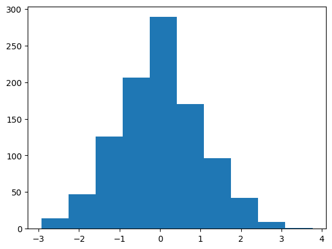

```python
plt.hist(xs);plt.show()
```

### Image Processing

`([((+)/* 0 (x::Arr (7 × 7) float))%ℝ(:x)] ⨳ {7,7})` applies a 7x7 mean filter to a 2-dimensional array.

We can use [Pillow](https://python-pillow.org/) to apply it to an image:

```python
from PIL import Image; import numpy as np
```

```python
bw=Image.open('./data/frog.png').convert("L")
```

```python
arr=np.array(bw).astype(np.float64)
```

```python
import apple
```

```python
conv=apple.jit('([((+)/* 0 (x::Arr (7 × 7) float))%ℝ(:x)] ⨳ {7,7})')
```

```python
blur=conv(arr)
```

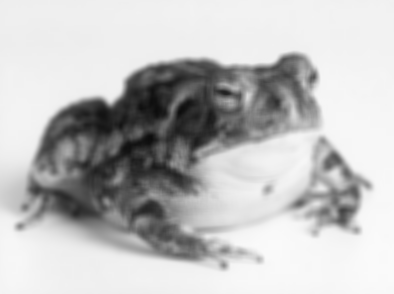

```python
display(Image.fromarray(blur).convert("RGB"))
```

### Random Walks

Cliff Reiter points out that we can simulate a random walk by simply scanning an array of random values, viz.

```python
(+)Λ (𝔯 _1 1 :: Vec 200 int)
```

```python
import apple
```

```python
random_walk=apple.jit('(+)Λ (𝔯 _1 1 :: Vec 200 int)')
```

```python
import matplotlib.pyplot as plt
```

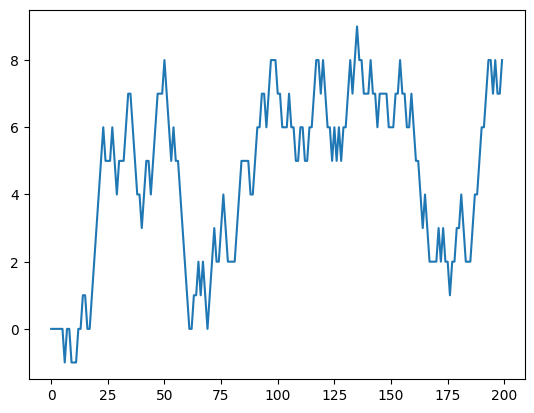

```python
plt.plot(random_walk())
```

```python
gaussian_walk=apple.jit("(+)Λ ([cos.(2*𝜋*x)*√(_2*_.y)]`(𝔯 0 1::Vec 100 float) (𝔯 0 1))")
```

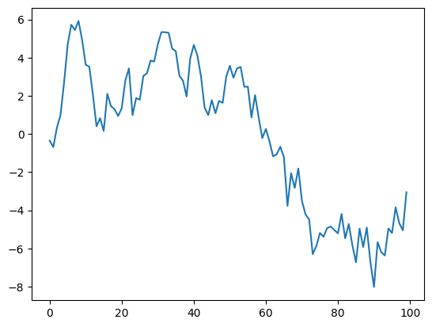

```python
plt.plot(gaussian_walk())
```

### Lorenz Attractor

We use `gen.` in place of a [less efficient for loop](https://matplotlib.org/stable/gallery/mplot3d/lorenz_attractor.html).

Apple has support for efficient tuples, while higher-rank arrays are more common in the NumPy ecosystem.

```python
# https://matplotlib.org/stable/gallery/mplot3d/lorenz_attractor.html
import matplotlib.pyplot as plt;import numpy as np; import apple
```

```python
# s=10, r=28, b=2.667
lorenz=apple.jit('''
{ s ← 10; r ← 28; b ← 8%3
; ∇ ← λ(x,y,z). (s*(y-x),r*x-y-x*z,x*y-b*z)
; sp ← λ(x0,y0,z0).λ(x1,y1,z1). (x0+x1,y0+y1,z0+z1)
; ms ← λr.λ(x,y,z). (r*x,r*y,r*z)
; gen. (0,1,1.05) [sp x (ms 0.01 (∇x))] 10000
}
''')
```

```python
def r3(x):
    p1=np.vectorize(lambda x: x[0])
    p2=np.vectorize(lambda x: x[1])
    p3=np.vectorize(lambda x: x[2])
    return np.stack([p1(x),p2(x),p3(x)])
```

```python
xyzs=r3(lorenz())
```

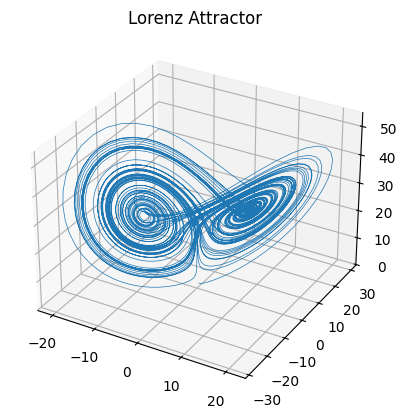

```python
ax = plt.figure().add_subplot(projection='3d')

ax.plot(*xyzs, lw=0.5)
ax.set_title("Lorenz Attractor")

plt.show()
```